# Project I

## The Degrees Dataset

### Part 1: Introduction

We analyzed the degree data and this data contains the temperature (in Fahrenheit) of a particular city in the US for a particular month. We are interested in answering the question “is the median temperature significantly above 77 degrees Fahrenheit (which was last years temperature)?”. This question can help us answer if the temperature is increasing compared to last year. I will use the normal approximation to the binomial distribution.

Group 1 (Group A) is Female and Group 2 (Group B) is Male.

### Part 2: Summary

Below is a histogram of the data “degrees.csv”. Based on the histogram and the boxplot below, the data is skewed, therefore it is not normally distributed. So it would be more intuitive to test the median instead of the mean since the median is not affected by outliers. This is why the non-parametric test, normal approximation to the binomial distribution should be used there.

### Part III: Analysis

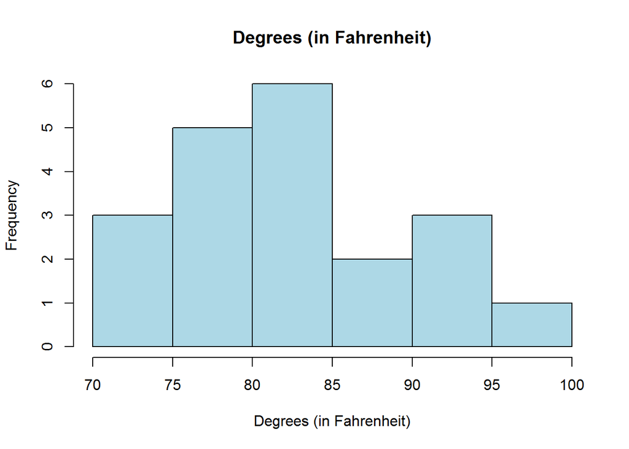

```r
library(BSDA)

degrees = c(81,83,87,92,91,78,73,81,93,96,79,80,84,86,82,85,77,72,73,80)
n = length(degrees)

hist(degrees, col = "lightblue", main = "Degrees (in Fahrenheit)",
     xlab = "Degrees (in Fahrenheit)", ylab = "Frequency")
```

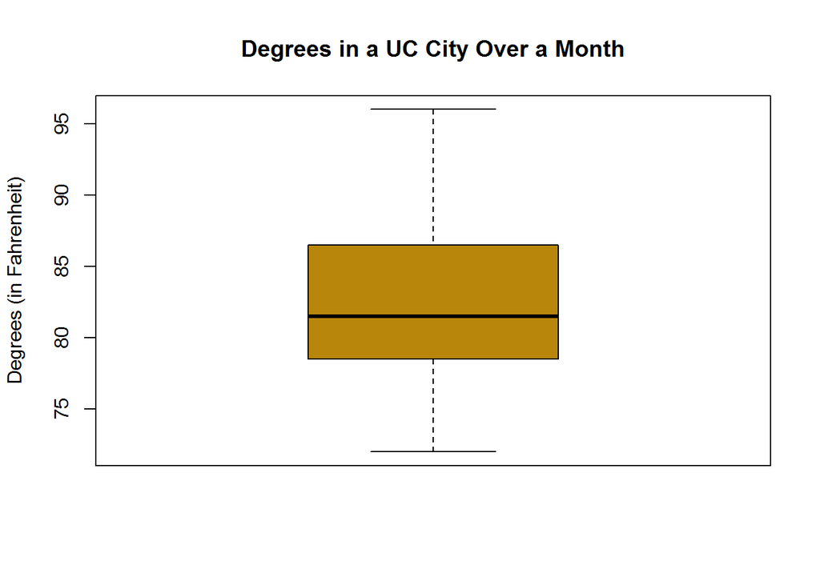

```r
boxplot(degrees, col = "darkgoldenrod",
        main = "Degrees in a UC City Over a Month",
        ylab = "Degrees (in Fahrenheit)")
```

Based on both the boxplot and histogram above, the degrees data is skewed; therefore, it is not normally distributed.

We can see that it is skewed. Since the data is not normally distributed (skewed) and the total number of observations is less than 30, the normal approximation to the binomial distribution test would be appropriate.

The appropriate null and alternative hypotheses are: $H_{0}: \theta_{m} \leq 77$ vs $H_{a}: \theta > 77$

Analysis of data:

```r
mean(degrees)
```

```
## [1] 82.65
```

```r
var(degrees)
```

```
## [1] 45.60789
```

```r
sd(degrees)
```

```
## [1] 6.753362
```

```r
median(degrees)
```

```
## [1] 81.5
```

```r
the.CI = SIGN.test(degrees, md = 77, alternative = "two.sided", conf.level = 0.95)
```

```
##
##  One-sample Sign-Test
##
## data:  degrees
## s = 16, p-value = 0.004425
## alternative hypothesis: true median is not equal to 77
## 95 percent confidence interval:
##  79.11647 85.88353
## sample estimates:
## median of x
##        81.5
```

```r
the.CI
```

```
##                   Conf.Level  L.E.pt  U.E.pt
## Lower Achieved CI     0.8847 80.0000 85.0000
## Interpolated CI       0.9500 79.1165 85.8835
## Upper Achieved CI     0.9586 79.0000 86.0000
```

Confidence Interval: (79.1165, 85.8835)

```r
X = degrees
B = sum(X > 77) #How many data points are larger than the hypothesized median
n = length(X) #The number of data points
Zs = (B - n*0.50)/sqrt(0.25*n) #The test-statistic
Zs
```

```
## [1] 2.683282
```

```r
p.value = pnorm(Zs,lower.tail= FALSE) #The p-value
p.value
```

```
## [1] 0.003645179
```

**Approximate value:**

Test-Statistic: 2.683283

p-value: 0.003645179

Conclusion: Reject $H_{0}$

**Exact value:**

Test-Statistic: -

p-value: 0.004425

Conclusion: Reject $H_{0}$

### Part IV: Interpretation

We are 95% confident that the true median lies between 79.1165 and 85.8835. The probably of observing our data or more extreme is 0.003645179. Since our p-value (both the approximate and exact value) is less than any reasonable alpha, we reject H0. Our p-value is also less than the test-statistic, so we also draw the same conclusion of rejecting H0.This means we cannot conclude that the median is less than or equal to 77 and that the true median is greater than 77. This can also be seen in our confidence interval because our confidence interval does not cover 77.

### Part V: Conclusion

In conclusion, we reject H0 and conclude that the median is not less than or equal to 77. The median is above 77.

## The Prison Dataset

### Part I: Intrudction

Using the prison data, we are interested in answering the question does sentencing length differ by gender? The data contains information about the lengths of sentences (in years) for crimes of similar severity for males and females. This is question is of interest because if there is a difference, it may show a bias in the legal system towards one of the genders to get longer sentencing in comparison to the other. To approach this problem, we used the Wilcoxon Rank Sum Test.

### Part II: Summary

```r
library(FSA)
library(coin)
```

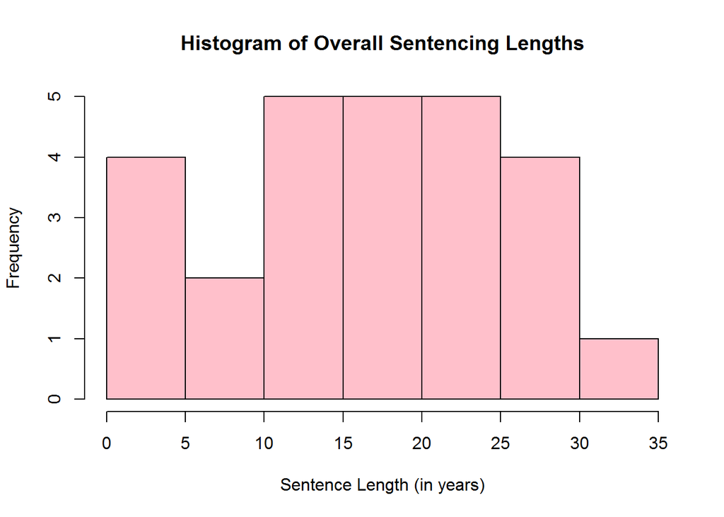

```r
prison = read.csv("prison.csv", header = TRUE)
prison$Rank = rank(prison$Length)

hist(prison$Length,
     main = "Histogram of Overall Sentencing Lengths",
     xlab = "Sentence Length (in years)", col = "pink")
```

To check for overall normality, we plotted a histogram of all the sentence lengths regardless of gender. Visually, it is easy to see that the data is not normal.

Next, we plotted boxplots and histograms for the data specific for each gender. Visually, from the gender specific histograms we see that neither the male nor females have perfectly normal distributions. Similarly, from the boxplots we can see that the data is not perfectly normal and the males generally have longer sentencing lengths than the females and the females have more wide spread sentencing lengths:

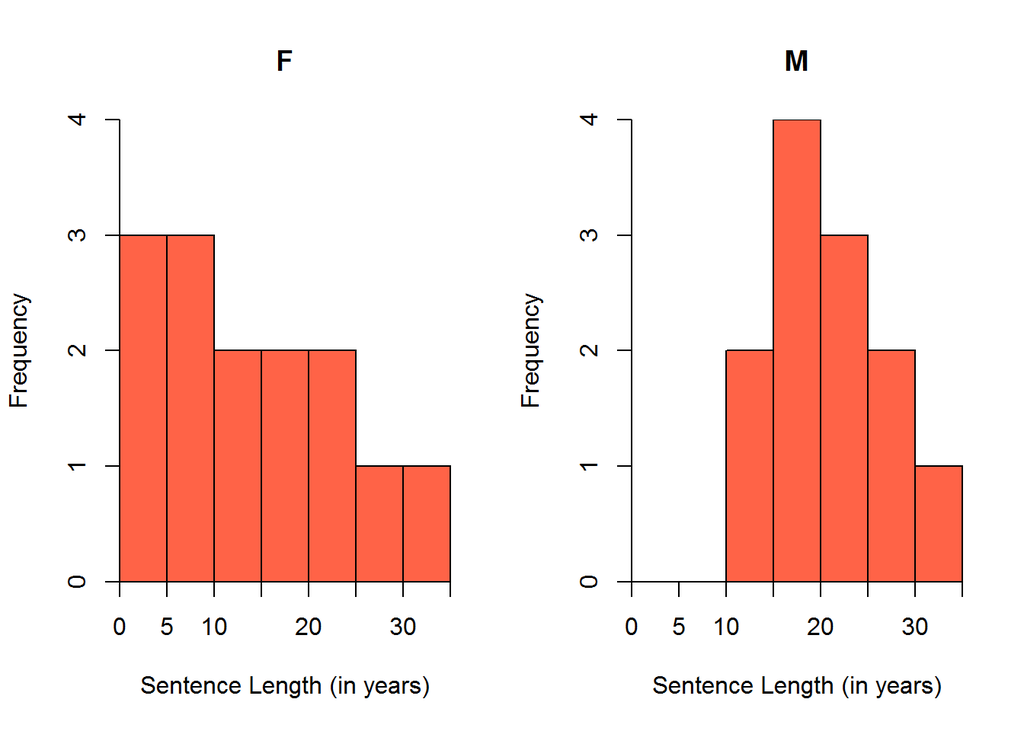

```r
hist(Length ~ Gender, prison,
     main = "Histogram: Female vs Male Prison Sentence Length",
     xlab = "Sentence Length (in years)",
     col = "tomato")
```

The histogram above shows that for females (histogram to the left) is skewed. The histogram for males (histogram to the right) looks almost normally distributed.

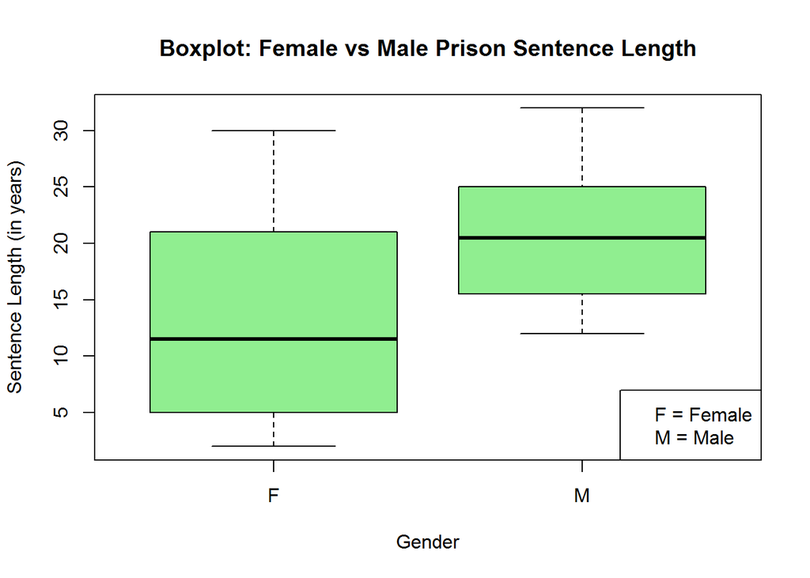

```r
boxplot(Length ~ Gender, prison,
        main = "Boxplot: Female vs Male Prison Sentence Length",
        ylab = "Sentence Length (in years)",
        xlab = "Gender", col = "lightgreen")
legend("bottomright", c("F = Female", "M = Male"))
```

The boxplot above shows that for males, it is mostly symmetric, while for females the data is skewed.

Based on the histogram and boxplot, we chose to use the Wilcoxon Rank Sum Test because the distributions are skewed and we are interested in checking if the means of the distributions are equal. We chose to focus on the mean because there are no prominent outliers in the data.

Analysis of data:

```r
choose(26, 12)
```

```
## [1] 9657700
```

Total number of permutations: 9657700.

```r
mean(prison$Length)
```

```
## [1] 16.69231
```

```r
sd(prison$Length)
```

```
## [1] 8.53121
```

```r
var(prison$Length)
```

```
## [1] 72.78154
```

```r
prison_means = aggregate(Length ~ Gender, data = prison, mean)$Length
prison_means
```

```
## [1] 13.28571 20.66667
```

```r
prison_sd = aggregate(Length ~ Gender, data = prison, sd)$Length
prison_sd
```

```
## [1] 9.067512 6.020168
```

```r
prison_nums = aggregate(Length ~ Gender, data = prison, length)$Length
prison_nums
```

```
## [1] 14 12
```

**Summary Statistics Per Group:**

*Female:*

Sample Size: 14

Mean: 13.28571

Variance: 82.21978

Standard Deviation: 9.067512

*Male:*

Sample Size: 12

Mean: 20.66667

Variance: 36.24242

Standard Deviation: 6.020168

**Summary Statistics Regardless of Groups:**

Sample Size: 26

Mean: 16.69231

Variance: 72.78154

Standard Deviation: 8.53121

### Part III: Analysis

We are testing whether males and females have the same sentencing length. Letting Group 1 (Group A) be the females and Group 2 (Group B) be the males, we ended up with the null and alternative hypotheses of:

$H_{0}: F_{1}(x) = F_{2}(x)$ vs $H_{a}: F_{1}(x) \geq F_{2}(x) \text{ or } F_{1}(x) \leq F_{2}(x)$

```r
wilcox_test(Length ~ Gender, data = prison, distribution = "exact",alternative = "two.sided")
```

```
##
##  Exact Wilcoxon-Mann-Whitney Test
##
## data:  Length by Gender (F, M)
## Z = -2.1617, p-value = 0.02988
## alternative hypothesis: true mu is not equal to 0
```

```r
the.test = wilcox_test(Length ~ Gender, data = prison, conf.level = 0.95, conf.int = TRUE)
as.numeric(confint(the.test)$conf.int)
```

```
## [1] -14.9999800  -0.9999276
```

### Part IV: Interpretation

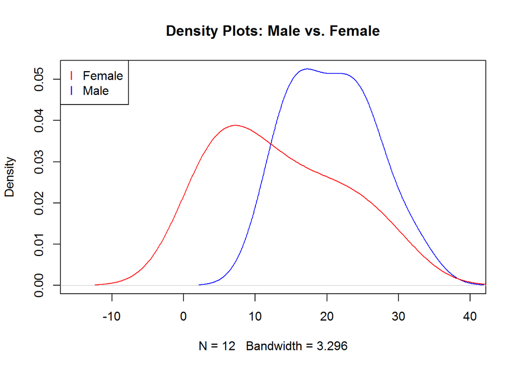

```r
plot(density(prison$Length[1:12]), col = ("blue"),
     main = "Density Plots: Male vs. Female", xlim = c(-15,40))
lines(density(prison$Length[13:26]), col = "red")
legend("topleft", c("Female", "Male"),
       pch = "l", col = c("red", "blue"))
```

Our p-value is 0.02988, so the probably of observing our data or more extreme is 0.02988. At 0.05 level of significance, we reject the null hypothesis that the two distributions are equal. Our confidence interval for the shift parameter is [-14.99, -0.999]. Since this interval does not cross zero, it is also not compatible with the null hypothesis that the distributions are the same. Also, we can see that group B (the male sample) is larger than group A (the female sample) because the confidence interval is completely less than 0.

### Part V: Conclusion

We reject H0; therefore, the means are different. This can also be seen in our confidence interval. Since both the confidence intervals are both negative, this means that the males (Group 2/B) has a longer sentencing time than females (Group 1/A).

## Code Appendix

```r
library(BSDA)

degrees = c(81,83,87,92,91,78,73,81,93,96,79,80,84,86,82,85,77,72,73,80)
n = length(degrees)

hist(degrees, col = "lightblue", main = "Degrees (in Fahrenheit)",
     xlab = "Degrees (in Fahrenheit)", ylab = "Frequency")
boxplot(degrees, col = "darkgoldenrod",
        main = "Degrees in a UC City Over a Month",
        ylab = "Degrees (in Fahrenheit)")
mean(degrees)
var(degrees)
sd(degrees)
median(degrees)
the.CI = SIGN.test(degrees, md = 77, alternative = "two.sided", conf.level = 0.95)
the.CI
X = degrees
B = sum(X > 77) #How many data points are larger than the hypothesized median
n = length(X) #The number of data points
Zs = (B - n*0.50)/sqrt(0.25*n) #The test-statistic
Zs
p.value = pnorm(Zs,lower.tail= FALSE) #The p-value
p.value
library(FSA)
library(coin)

prison = read.csv("prison.csv", header = TRUE)
prison$Rank = rank(prison$Length)

hist(prison$Length,
     main = "Histogram of Overall Sentencing Lengths",
     xlab = "Sentence Length (in years)", col = "pink")
hist(Length ~ Gender, prison,
     main = "Histogram: Female vs Male Prison Sentence Length",
     xlab = "Sentence Length (in years)",
     col = "tomato")
boxplot(Length ~ Gender, prison,
        main = "Boxplot: Female vs Male Prison Sentence Length",
        ylab = "Sentence Length (in years)",
        xlab = "Gender", col = "lightgreen")
legend("bottomright", c("F = Female", "M = Male"))
choose(26, 12)
mean(prison$Length)
sd(prison$Length)
var(prison$Length)
prison_means = aggregate(Length ~ Gender, data = prison, mean)$Length
prison_means
prison_sd = aggregate(Length ~ Gender, data = prison, sd)$Length
prison_sd
prison_nums = aggregate(Length ~ Gender, data = prison, length)$Length
prison_nums
wilcox_test(Length ~ Gender, data = prison, distribution = "exact",alternative = "two.sided")

the.test = wilcox_test(Length ~ Gender, data = prison, conf.level = 0.95, conf.int = TRUE)
as.numeric(confint(the.test)$conf.int)
plot(density(prison$Length[1:12]), col = ("blue"),
     main = "Density Plots: Male vs. Female", xlim = c(-15,40))
lines(density(prison$Length[13:26]), col = "red")
legend("topleft", c("Female", "Male"),
       pch = "l", col = c("red", "blue"))
```